# **Panorama da inflação**

Os principais índices de inflação do Brasil, apontam em setembro de 2019 um recuo da inflação de em média **-0.03%**. Com esse resultado, no ano a inflação acumula uma variação média positiva de **3.07%**, e em 12 meses uma variação média acumulada de **3.06%**.

|  | Variação mensal | Variação acumulada no ano | Variação acumulada em 12 meses |
| --- | --- | --- | --- |
| IPCA | -0.04% | 2.49% | 2.89% |
| INPC | -0.05% | 2.63% | 2.92% |
| IGP-M | -0.01% | 4.08% | 3.37% |
| IGP-DI | 0.5% | 4.32% | 3% |
| IPA | 0.68% | 0.05% | 0.03% |
| IPC | 0% | 2.32% | 3.51% |
| INCC | 0.46% | 3.2% | 4.35% |

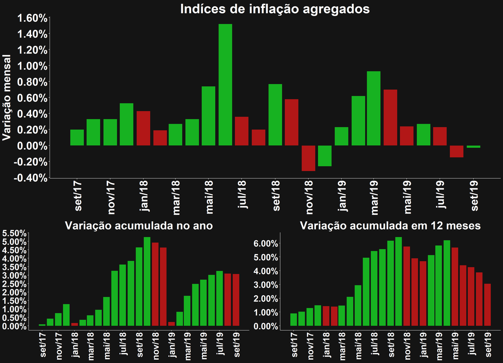

Índices selecionados para a média: IPCA, INPC e IGP-M.

# IPCA

O Indíce de Preços ao Consumidor Amplo (IPCA) variou -0.04% em setembro, valor inferior ao mesmo período do ano anterior quando apresentou uma taxa de 0.48%. Com esse resultado o indíce acumula no ano uma variação positiva de 2.49%, e em 12 meses uma variação positiva de 2.89%.

|  | 09/2018 | 08/2019 | 09/2019 |
| --- | --- | --- | --- |
| Variação mensal | 0.48% | 0.11% | -0.04% |
| Variação acumulada no ano | 3.34% | 2.54% | 2.49% |
| Variação acumulada em 12 meses | 4.53% | 3.43% | 2.89% |

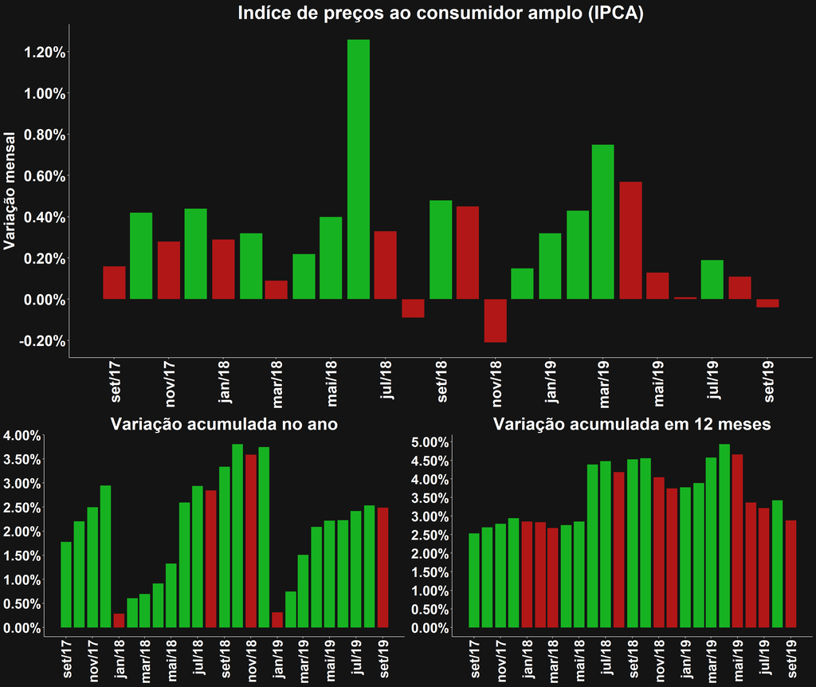

Os grupos que tiveram maior resultado positivo foram Saúde e cuidados pessoais (0.58%) e Vestuário (0.27%), e negativo Artigos de residência (-0.76%) e Alimentação e bebidas (-0.43%).

|  | Variação mensal | Variação acumulada no ano | Peso mensal |
| --- | --- | --- | --- |
| Alimentação e bebidas | -0.43% | 2.1% | 24.63% |
| Habitação | 0.02% | 4.65% | 16.16% |
| Artigos de residência | -0.76% | 0.56% | 3.93% |
| Vestuário | 0.27% | -0.24% | 5.62% |
| Transportes | 0% | 1.25% | 18.14% |
| Saúde e cuidados pessoais | 0.58% | 4.33% | 12.21% |
| Despesas pessoais | 0.04% | 2.24% | 10.86% |
| Educação | 0.04% | 4.43% | 5.01% |
| Comunicação | -0.01% | 0.45% | 3.44% |

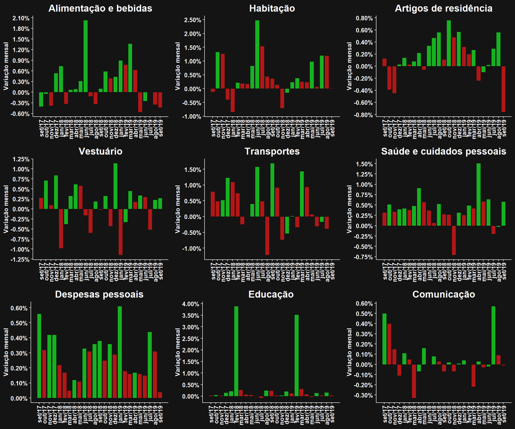

A nível de sub-itens os que mais influenciaram positivamente no resultado em relação ao seu peso foram Perfume (3.96%%) e Plano de saúde (0.57%%), e negativamente Tomate (-16.17%%) e Mamão (-18.95%%).

|  | Variação mensal | Variação acumulada no ano | Peso mensal |
| --- | --- | --- | --- |
| Perfume | 3.96% | 5.5% | 0.89% |
| Leite longa vida | 1.58% | 8.57% | 0.93% |
| Plano de saúde | 0.57% | 6.35% | 4.29% |
| Aluguel residencial | 0.42% | 3.18% | 3.82% |

|  | Variação mensal | Variação acumulada no ano | Peso mensal |
| --- | --- | --- | --- |
| Tomate | -16.17% | -35.52% | 0.24% |
| Mamão | -18.95% | 16.25% | 0.13% |
| Batata-inglesa | -8.42% | 20.15% | 0.26% |
| Cebola | -9.89% | 43.65% | 0.21% |

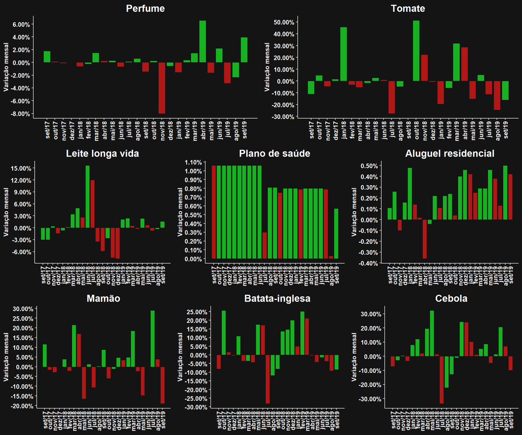

# INPC

O Indíce Nacional de Preços ao Consumidor (INPC) variou -0.05% em setembro, valor inferior ao mesmo período do ano anterior quando apresentou uma taxa de 0.3%. Com esse resultado o indíce acumula no ano uma variação positiva de 2.63%, e em 12 meses uma variação positiva de 2.92%.

|  | 09/2018 | 08/2019 | 09/2019 |
| --- | --- | --- | --- |
| Variação mensal | 0.3% | 0.12% | -0.05% |
| Variação acumulada no ano | 3.14% | 2.68% | 2.63% |
| Variação acumulada em 12 meses | 3.97% | 3.28% | 2.92% |

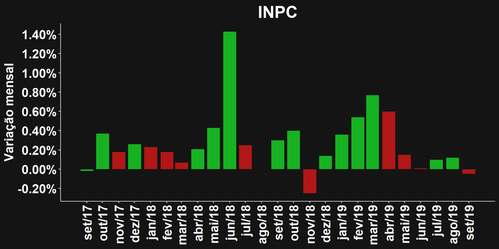

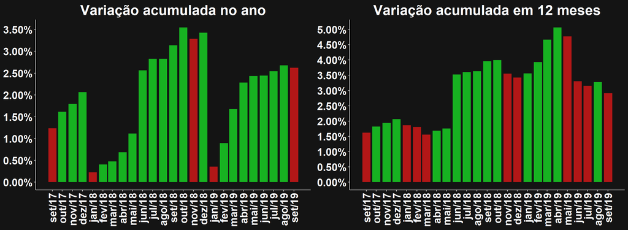

# IGP-M

O Indíce Geral de Preços de Mercado (IGP-M) variou -0.01% em setembro, valor inferior ao mesmo período do ano anterior quando apresentou uma taxa de 1.52%. Com esse resultado o indíce acumula no ano uma variação positiva de 4.08%, e em 12 meses uma variação positiva de 3.37%.

|  | 09/2018 | 08/2019 | 09/2019 |
| --- | --- | --- | --- |
| Variação mensal | 1.52% | -0.67% | -0.01% |
| Variação acumulada no ano | 7.48% | 4.09% | 4.08% |
| Variação acumulada em 12 meses | 10.04% | 4.95% | 3.37% |

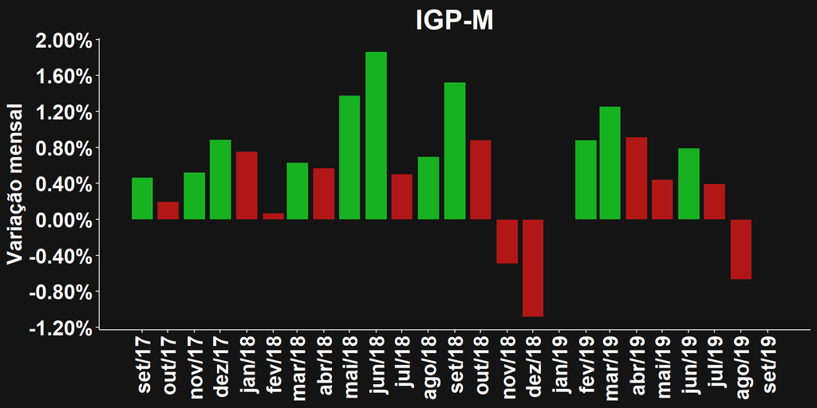

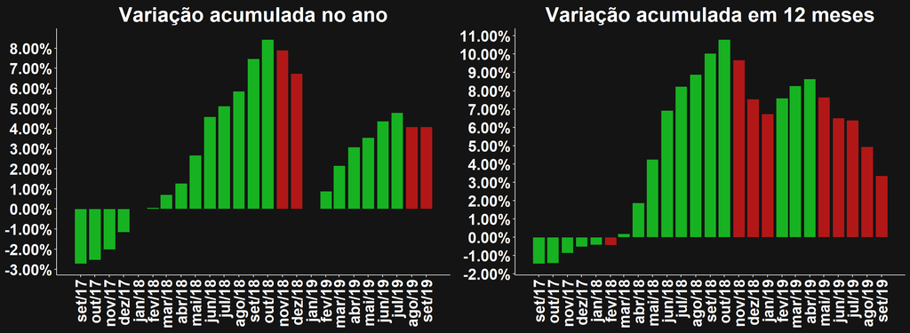

# IGP-DI

|  | 09/2018 | 08/2019 | 09/2019 |
| --- | --- | --- | --- |
| Variação mensal | 1.79% | -0.51% | 0.5% |
| Variação acumulada no ano | 7.92% | 3.79% | 4.32% |
| Variação acumulada em 12 meses | 10.33% | 4.32% | 3% |

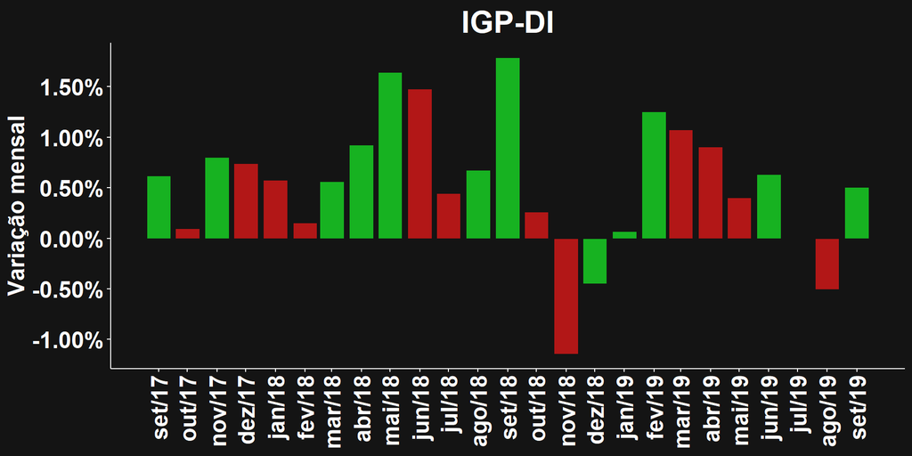

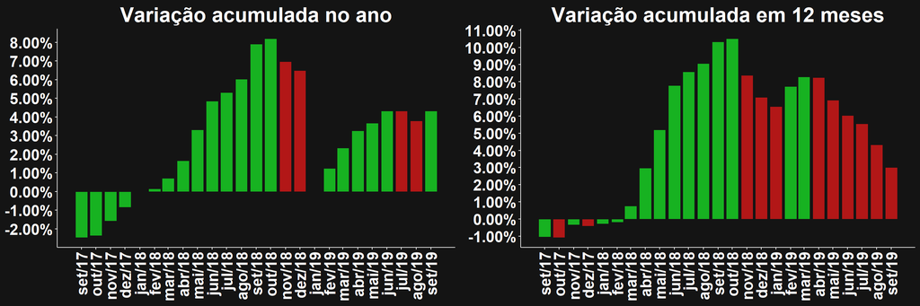

|  | 09/2018 | 08/2019 | 09/2019 |
| --- | --- | --- | --- |
| Variação mensal | 2.54% | -0.9% | 0.68% |
| Variação acumulada no ano | 0.11% | 0.04% | 0.05% |
| Variação acumulada em 12 meses | 0.14% | 0.04% | 0.03% |

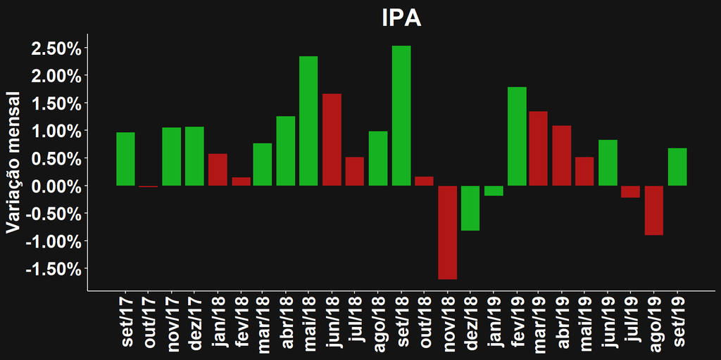

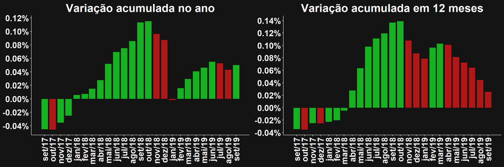

O Indíce de Preços ao Consumidor (IPC), integrante do IGP-DI com peso de 30%, apresentou variação de 0% em setembro, valor inferior ao mesmo período do ano anterior quando apresentou uma taxa de 0.45%. Com esse resultado o indíce acumula no ano uma variação positiva de 2.32%, e em 12 meses uma variação positiva de 3.51%.

|  | 09/2018 | 08/2019 | 09/2019 |
| --- | --- | --- | --- |
| Variação mensal | 0.45% | 0.17% | 0% |
| Variação acumulada no ano | 3% | 2.32% | 2.32% |
| Variação acumulada em 12 meses | 4.64% | 3.97% | 3.51% |

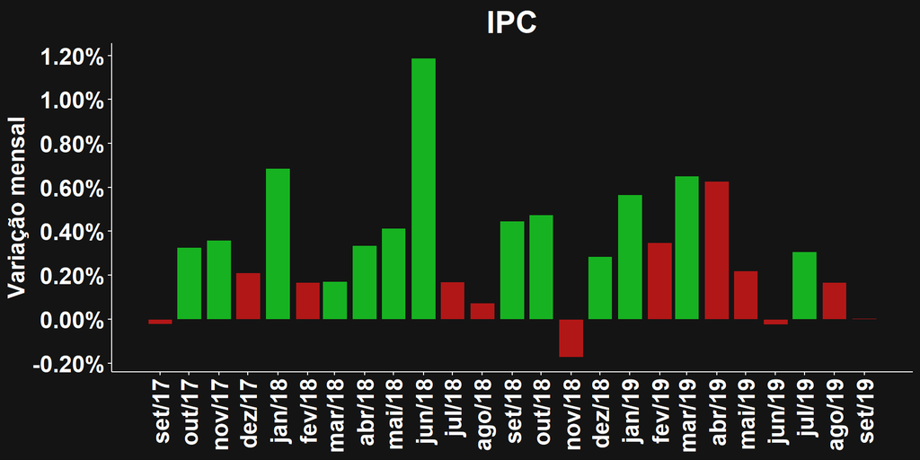

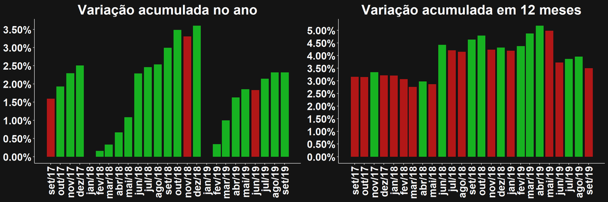

O Indíce Nacional de Custos de Construção (INCC), integrante do IGP-DI com peso de 10%, apresentou variação de 0.46% em setembro, valor superior ao mesmo período do ano anterior quando apresentou uma taxa de 0.23%. Com esse resultado o indíce acumula no ano uma variação positiva de 3.2%, e em 12 meses uma variação positiva de 4.35%.

|  | 09/2018 | 08/2019 | 09/2019 |
| --- | --- | --- | --- |
| Variação mensal | 0.23% | 0.42% | 0.46% |
| Variação acumulada no ano | 2.89% | 2.73% | 3.2% |
| Variação acumulada em 12 meses | 3.92% | 4.11% | 4.35% |

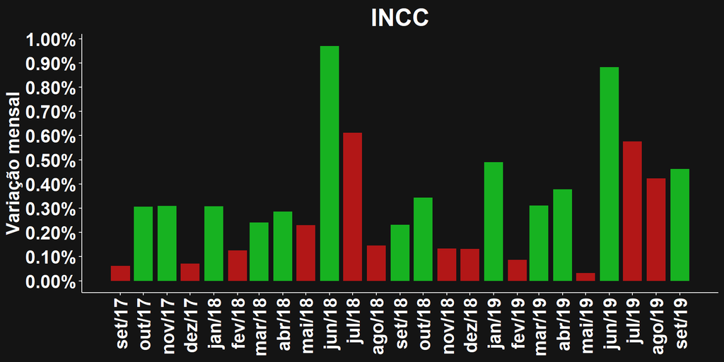

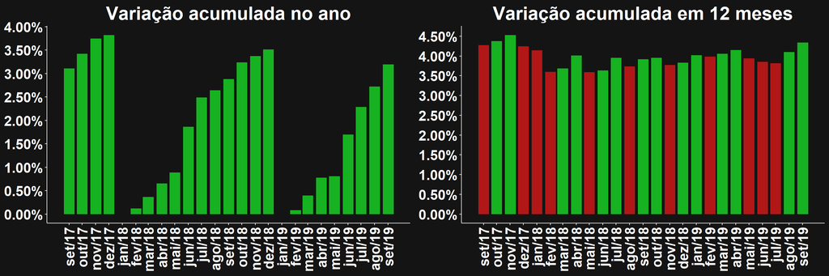

# Estatísticas

As estatísticas descritivas a seguir são feitas com base nos últimos 48 meses, e tem como objetivo possibilitar a avaliação do resultado observado em comparação aos períodos anteriores.

|  | Minimo | 1 Quartil | Mediana | Media | 3 Quartil | Maximo | Desvio Padrão |
| --- | --- | --- | --- | --- | --- | --- | --- |
| IPCA | -0.23% | 0.17% | 0.32% | 0.37% | 0.46% | 1.27% | 0.33% |
| INPC | -0.3% | 0.12% | 0.26% | 0.36% | 0.49% | 1.51% | 0.39% |
| IGP-M | -1.1% | 0.08% | 0.5% | 0.45% | 0.88% | 1.89% | 0.73% |
| IGP-DI | -1.24% | 0.06% | 0.44% | 0.44% | 0.85% | 1.79% | 0.73% |
| IPA | -1.96% | -0.05% | 0.51% | 0.47% | 1.09% | 2.54% | 1.05% |
| IPC | -0.32% | 0.17% | 0.34% | 0.4% | 0.53% | 1.78% | 0.36% |
| INCC | -0.02% | 0.16% | 0.32% | 0.38% | 0.49% | 1.93% | 0.32% |

Levando em consideração o desvio padrão de cada indíce, proporcionalmente os que mais se afastaram da média foram o IPCA, o IPC e o INPC.

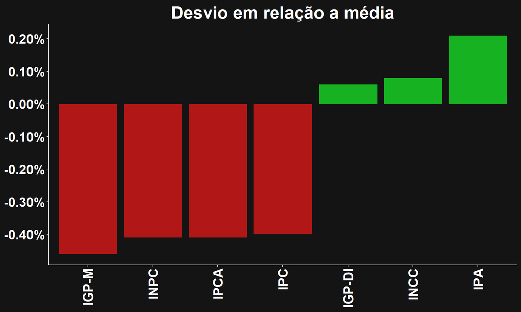

**João Victor Gomes**  
**jvg.santana@gmail.com**  
**[linkedin.com/in/jvictorgomes](https://www.linkedin.com/in/jvictorgomes/)**